# Analisis Klaster dalam Pengelolaan Sampah: Identifikasi Penyumbang Sampah Terpilah dan Non-Terpilah Terbanyak di Kota Magelang

Tujuan:

- Menganalisis pola pengelolaan sampah di Kota Magelang berdasarkan klasterisasi supplier berdasarkan jenis sampah terpilah dan non-terpilah.
- Mengidentifikasi daerah-daerah dengan kontribusi terbesar dalam penyumbangan sampah terpilah dan non-terpilah.

# 1. Import Library

```python
from google.colab import files

import pandas as pd
import numpy as np
import seaborn as sns                       #visualisation
import matplotlib.pyplot as plt             #visualisation
import pickle

from sklearn.preprocessing import LabelEncoder
from sklearn.preprocessing import MinMaxScaler
from sklearn.preprocessing import StandardScaler

from sklearn import metrics
from sklearn.model_selection import train_test_split, cross_val_score
from sklearn.metrics import confusion_matrix, classification_report
from sklearn.metrics import accuracy_score
from sklearn.metrics import ConfusionMatrixDisplay
from sklearn.model_selection import GridSearchCV

import time

%matplotlib inline
sns.set(color_codes=True)
```

```python
from google.colab import drive
drive.mount('/content/drive')
```

# 2. Read Data

```python
df = pd.read_csv('/content/drive/MyDrive/B/Freelance/Project Waste Management - Braincore/metadata_cleaned.csv')
```

```python
df.head()
```

|  | No | tanggal | hari | bulan | tahun | nopol | barang | supplier | netto_kg | jam | ... | admin | kelurahan | kecamatan | kabkot | curah_hujan_kecamatan | hari_hujan_kecamatan | Luas | Jml_RT | Jml_RW | Jml_penduduk |
| --- | --- | --- | --- | --- | --- | --- | --- | --- | --- | --- | --- | --- | --- | --- | --- | --- | --- | --- | --- | --- | --- |
| 0 | 3 | 31/12/2023 | 31 | 12 | 2023 | AA 6249 XA | Sampah | dlh kota magelang | 300 | 15:31 | ... | Kurniawan BW | Kedungsari | Magelang Utara | Kota Magelang | 211.0 | 17.0 | 6.29 | 306.0 | 49.0 | 42224.0 |
| 1 | 4 | 31/12/2023 | 31 | 12 | 2023 | AA 8013 XA | Sampah | pasar rejowinangun | 550 | 15:15 | ... | Kurniawan BW | Rejowinangun Selatan | Magelang Selatan | Kota Magelang | 211.0 | 17.0 | 6.29 | 306.0 | 49.0 | 42224.0 |
| 2 | 5 | 31/12/2023 | 31 | 12 | 2023 | AA 8022 XA | Sampah | depo tidar selatan | 2270 | 13:51 | ... | Kurniawan BW | Tidar Utara | Magelang Selatan | Kota Magelang | 211.0 | 17.0 | 6.29 | 306.0 | 49.0 | 42224.0 |
| 3 | 6 | 31/12/2023 | 31 | 12 | 2023 | AA 9574 FA | Sampah | dlh kota magelang | 500 | 11:49 | ... | Eksta Gama Pratama Y | Kedungsari | Magelang Utara | Kota Magelang | 211.0 | 17.0 | 6.29 | 306.0 | 49.0 | 42224.0 |
| 4 | 7 | 31/12/2023 | 31 | 12 | 2023 | AA 8022 XA | Sampah | depo magersari | 1620 | 11:42 | ... | Eksta Gama Pratama Y | Magersari | Magelang Selatan | Kota Magelang | 211.0 | 17.0 | 6.29 | 306.0 | 49.0 | 42224.0 |

5 rows × 21 columns

```python
df.info()
```

```
<class 'pandas.core.frame.DataFrame'>
RangeIndex: 60962 entries, 0 to 60961
Data columns (total 21 columns):
 #   Column                 Non-Null Count  Dtype
---  ------                 --------------  -----
 0   No                     60962 non-null  int64
 1   tanggal                60962 non-null  object
 2   hari                   60962 non-null  int64
 3   bulan                  60962 non-null  int64
 4   tahun                  60962 non-null  int64
 5   nopol                  60962 non-null  object
 6   barang                 60962 non-null  object
 7   supplier               60962 non-null  object
 8   netto_kg               60962 non-null  int64
 9   jam                    60962 non-null  object
 10  sopir                  60962 non-null  object
 11  admin                  60962 non-null  object
 12  kelurahan              60962 non-null  object
 13  kecamatan              60962 non-null  object
 14  kabkot                 60962 non-null  object
 15  curah_hujan_kecamatan  60962 non-null  float64
 16  hari_hujan_kecamatan   60962 non-null  float64
 17  Luas                   60962 non-null  float64
 18  Jml_RT                 60962 non-null  float64
 19  Jml_RW                 60962 non-null  float64
 20  Jml_penduduk           60962 non-null  float64
dtypes: float64(6), int64(5), object(10)
memory usage: 9.8+ MB
```

Tahapan `df.info()` bertujuan untuk memberikan informasi tentang DataFrame, seperti jumlah baris dan kolom, serta tipe data yang terdapat dalam setiap kolom. Hasilnya akan memberikan gambaran singkat tentang struktur data yang sedang Anda kerjakan.

Dari hasil diatas, terdapat 21 kolom dengan 60962 entri. Informasi seperti ini sangat berguna untuk memahami data yang sedang diolah.

# 3. Data Preprocessing

```python
df.isnull().sum()
```

```
No                       0
tanggal                  0
hari                     0
bulan                    0
tahun                    0
nopol                    0
barang                   0
supplier                 0
netto_kg                 0
jam                      0
sopir                    0
admin                    0
kelurahan                0
kecamatan                0
kabkot                   0
curah_hujan_kecamatan    0
hari_hujan_kecamatan     0
Luas                     0
Jml_RT                   0
Jml_RW                   0
Jml_penduduk             0
dtype: int64
```

Tahapan tersebut adalah untuk memeriksa apakah terdapat nilai-nilai null (kosong) dalam setiap kolom dari DataFrame `df`. Dengan menggunakan metode `.isnull()` pada DataFrame, kita dapat mengidentifikasi di mana saja nilai-nilai tersebut kosong, kemudian dengan metode `.sum()` kita menghitung jumlah nilai null di setiap kolom.

Hasilnya adalah bahwa tidak ada nilai null dalam setiap kolom DataFrame `df`, karena hasilnya adalah 0 untuk setiap kolom. Hal ini menunjukkan bahwa data yang dimiliki tidak mengandung nilai kosong, yang artinya data tersebut lengkap (tidak ada yang hilang) dan siap untuk dianalisis atau diproses lebih lanjut.

## Menghapus kolom-kolom yang tidak digunakan

```python
df_cleaned = df.drop(columns=["No", "tanggal","jam","nopol", "sopir","admin","kabkot"])
```

Tahapan di atas bertujuan untuk membersihkan DataFrame (`df`) dengan menghapus kolom-kolom yang tidak digunakan atau tidak diperlukan untuk analisis lebih lanjut. Kolom yang dihapus adalah "No", "tanggal", "jam", "nopol", "sopir", "admin", dan "kabkot".

Hasilnya adalah DataFrame baru yang disebut `df_cleaned`, yang berisi data yang lebih ringkas dan relevan, tanpa kolom-kolom yang telah dihapus. Ini membantu mempercepat analisis data dan mengurangi kompleksitas yang tidak perlu.

```python
df_cleaned = df_cleaned.dropna()
```

Tahapan di atas bertujuan untuk menghapus baris dari DataFrame `df_cleaned` yang mengandung nilai-nilai yang hilang (NaN). Hasilnya adalah DataFrame baru yang telah dibersihkan dari baris-baris yang memiliki nilai yang hilang.

```python
df_cleaned.isnull().sum()
```

```
hari                     0
bulan                    0
tahun                    0
barang                   0
supplier                 0
netto_kg                 0
kelurahan                0
kecamatan                0
curah_hujan_kecamatan    0
hari_hujan_kecamatan     0
Luas                     0
Jml_RT                   0
Jml_RW                   0
Jml_penduduk             0
dtype: int64
```

```python
df_cleaned.info()
```

```
<class 'pandas.core.frame.DataFrame'>
RangeIndex: 60962 entries, 0 to 60961
Data columns (total 14 columns):
 #   Column                 Non-Null Count  Dtype
---  ------                 --------------  -----
 0   hari                   60962 non-null  int64
 1   bulan                  60962 non-null  int64
 2   tahun                  60962 non-null  int64
 3   barang                 60962 non-null  object
 4   supplier               60962 non-null  object
 5   netto_kg               60962 non-null  int64
 6   kelurahan              60962 non-null  object
 7   kecamatan              60962 non-null  object
 8   curah_hujan_kecamatan  60962 non-null  float64
 9   hari_hujan_kecamatan   60962 non-null  float64
 10  Luas                   60962 non-null  float64
 11  Jml_RT                 60962 non-null  float64
 12  Jml_RW                 60962 non-null  float64
 13  Jml_penduduk           60962 non-null  float64
dtypes: float64(6), int64(4), object(4)
memory usage: 6.5+ MB
```

```python
df_cleaned.groupby('kelurahan').size().sort_values(ascending = False).head(20)
```

```
kelurahan
Kedungsari              16818
Potrobangsan             6107
Kramat Utara             4264
Magersari                4145
-                        3751
Kemiri Rejo              2435
Rejowinangun Selatan     2417
Tidar Utara              2398
Tidar Selatan            2359
Wates                    2063
Jurangombo Utara         1999
Magelang                 1984
Kramat Selatan           1979
Jurangombo Selatan       1761
Panjang                  1744
Jurangombo               1496
Gelangan                 1264
Jurangombo UTara          944
Cacaban                   551
Rejowinangun Utara        483
dtype: int64
```

Tahapan di atas merupakan proses pengelompokkan data berdasarkan kelurahan pada DataFrame `df_cleaned`, kemudian menghitung jumlah entri data yang memiliki kelurahan yang sama, dan akhirnya diurutkan dari yang terbanyak ke yang terendah.

Tujuan dari tahapan ini adalah untuk mengetahui distribusi data berdasarkan kelurahan dan mengidentifikasi kelurahan-kelurahan dengan jumlah entri data terbanyak.

Dari hasil analisis singkat di atas, dapat dilihat bahwa:

- Kelurahan Kedungsari memiliki jumlah entri data terbanyak dengan 16.818 entri.
- Kemudian diikuti oleh kelurahan Potrobangsan dengan 6.107 entri.
- Selanjutnya, terdapat kelurahan Kramat Utara dengan 4.264 entri.
- Lalu, Magersari dengan 4.145 entri.
- Sedangkan "Daerah lainnya" memiliki 3.751 entri data.

```python
df_cleaned.groupby('kecamatan').size().sort_values(ascending = False).head(20)
```

```
kecamatan
Magelang Utara      32844
Magelang Selatan    17738
Magelang Tengah     10380
dtype: int64
```

```python
df_cleaned.groupby('barang').size().sort_values(ascending = False).head(60)
```

```
barang
Sampah             59487
Sampah Terpilah     1468
0                      7
dtype: int64
```

```python
df_cleaned['kelurahan'] = df_cleaned['kelurahan'].replace('-', 'daerah lainnya')
```

```python
df_filtered = df_cleaned.copy()
```

# 4.Exploratory Data Analysis (EDA)

EDA atau Exploratory Data Analysis adalah sebuah proses investigasi awal pada data untuk menemukan pola, kecenderungan, anomali, atau insight-insight awal yang mungkin tersembunyi di dalamnya. Tujuannya adalah untuk memahami struktur dan karakteristik data sebelum melakukan analisis yang lebih mendalam atau membangun model.

## Check Distribusi Data

```python
statistics_data = []

for column in df_filtered.columns:
    if df_filtered[column].dtype in ['int64', 'float64']:
        column_stats = {
            "Nama Kolom": column,
            "Mean": df_filtered[column].mean(),
            "Median": df_filtered[column].median(),
            "Skewness": df_filtered[column].skew()
        }
        statistics_data.append(column_stats)

# Dataframe yang menampung Statitics Data
statistics_df = pd.DataFrame(statistics_data)
```

Tahapan di atas bertujuan untuk melakukan distribusi data pada DataFrame `df_filtered`. Proses ini dilakukan dengan mengiterasi setiap kolom dalam DataFrame, dan jika tipe data kolom adalah numerik (int64 atau float64), maka statistik seperti mean (rata-rata), median, dan skewness (skewness) dihitung untuk kolom tersebut. Hasil statistik kemudian disimpan dalam bentuk dictionary dan ditambahkan ke dalam list `statistics_data`.

Selanjutnya, list `statistics_data` digunakan untuk membuat DataFrame `statistics_df`, yang akan menampung semua statistik yang telah dihitung untuk setiap kolom numerik dalam DataFrame `df_filtered`.

Analisis singkat dari hasil ini dapat memberikan wawasan tentang distribusi data secara umum. Mean menunjukkan pusat massa data, median merepresentasikan nilai tengah dari data, dan skewness mengindikasikan seberapa condong distribusi data dari distribusi normal. Dengan menganalisis statistik ini, kita dapat memahami apakah data memiliki kecondongan (skewness) atau adanya pencilan (outliers), serta mendapatkan gambaran umum tentang bagaimana data tersebar.

```python
statistics_df
```

|  | Nama Kolom | Mean | Median | Skewness |
| --- | --- | --- | --- | --- |
| 0 | hari | 15.882730 | 16.00 | -0.007126 |
| 1 | bulan | 6.494767 | 7.00 | -0.038623 |
| 2 | tahun | 2020.960287 | 2021.00 | 0.055451 |
| 3 | netto_kg | 1314.508087 | 1000.00 | 1.132437 |
| 4 | curah_hujan_kecamatan | 238.502897 | 211.00 | 1.052124 |
| 5 | hari_hujan_kecamatan | 15.264017 | 17.00 | -0.756171 |
| 6 | Luas | 6.314622 | 6.29 | -0.637359 |
| 7 | Jml_RT | 319.291493 | 306.00 | 2.251425 |
| 8 | Jml_RW | 55.289016 | 49.00 | 0.976135 |
| 9 | Jml_penduduk | 42579.514353 | 42224.00 | 0.726480 |

```python
statistics_df['Nama Kolom'].unique() # Untuk melihat kolom apa saja yang ada
```

```
array(['hari', 'bulan', 'tahun', 'netto_kg', 'curah_hujan_kecamatan',
       'hari_hujan_kecamatan', 'Luas', 'Jml_RT', 'Jml_RW', 'Jml_penduduk'],
      dtype=object)
```

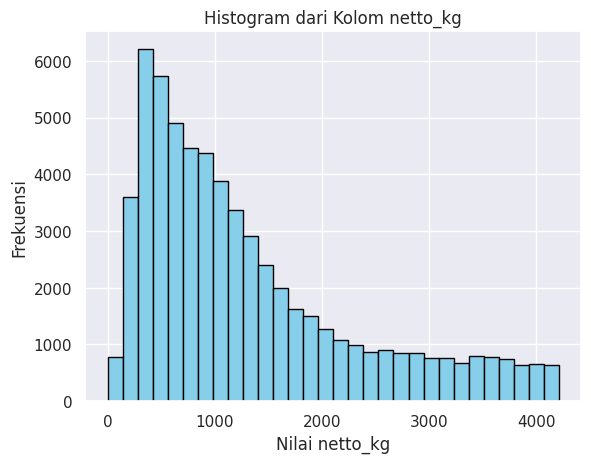

```python
# Membuat histogram dari kolom 'netto_kg'
plt.hist(df_filtered['netto_kg'], bins=30, color='skyblue', edgecolor='black')
plt.title('Histogram dari Kolom netto_kg')
plt.xlabel('Nilai netto_kg')
plt.ylabel('Frekuensi')
plt.grid(True)
plt.show()
```

Tahapan di atas bertujuan untuk membuat histogram dari kolom 'netto_kg' dalam dataset 'df_filtered'. Histogram ini membantu dalam visualisasi distribusi data dari kolom tersebut.

Analisis singkat hasilnya menunjukkan bahwa distribusi data 'netto_kg' cenderung tidak normal atau memiliki skewness. Hal ini terlihat dari bentuk histogram yang tidak simetris, mungkin cenderung miring ke salah satu sisi. Skewness ini bisa memberikan petunjuk tentang asimetri dalam data, yang penting untuk dipertimbangkan dalam analisis statistik lebih lanjut.

`Catatan :`

Distribusi data mengacu pada cara nilai-nilai dalam dataset didistribusikan atau tersebar. Tujuannya adalah untuk memahami pola dan karakteristik fundamental dari data tersebut. Distribusi data memberikan informasi tentang seberapa sering nilai-nilai tertentu muncul, sebaran relatif antara nilai-nilai, serta kecenderungan keseluruhan dari data tersebut.

## Check Outlier Data

```python
import pandas as pd

# Assuming df is your DataFrame
outliers_data = []

for column in df_filtered.columns:
    if df[column].dtype in ['int64', 'float64']:
        Q1 = df_filtered[column].quantile(0.25)
        Q3 = df_filtered[column].quantile(0.75)
        IQR = Q3 - Q1
        lower_fence = Q1 - 1.5 * IQR
        upper_fence = Q3 + 1.5 * IQR
        column_outliers = df_filtered[(df_filtered[column] < lower_fence) | (df_filtered[column] > upper_fence)]

        outliers_data.append({
            "Nama Kolom": column,
            "Outliers Count": len(column_outliers),
        })

# Create a new DataFrame for the outliers
outliers_df = pd.DataFrame(outliers_data)
```

```python
outliers_df
```

|  | Nama Kolom | Outliers Count |
| --- | --- | --- |
| 0 | hari | 0 |
| 1 | bulan | 0 |
| 2 | tahun | 0 |
| 3 | netto_kg | 2663 |
| 4 | curah_hujan_kecamatan | 2871 |
| 5 | hari_hujan_kecamatan | 0 |
| 6 | Luas | 17337 |
| 7 | Jml_RT | 6438 |
| 8 | Jml_RW | 0 |
| 9 | Jml_penduduk | 21941 |

Tahapan di atas bertujuan untuk menemukan outlier dalam set data Anda. Outlier adalah nilai yang secara signifikan berbeda dari sebagian besar data dalam sebuah dataset. Metode yang digunakan dalam tahapan ini adalah menggunakan metode IQR (Interquartile Range) untuk mengidentifikasi outlier dalam kolom-kolom numerik dari DataFrame Anda.

Hasil analisis menunjukkan jumlah outlier dalam setiap kolom numerik. Dari hasil tersebut, dapat disimpulkan bahwa:

- Kolom "netto_kg", "curah_hujan_kecamatan", "Luas", "Jml_RT", dan "Jml_penduduk" memiliki outlier.
- Kolom "hari", "bulan", "tahun", "hari_hujan_kecamatan", dan "Jml_RW" tidak memiliki outlier.

Dengan mengetahui outlier dalam dataset, Anda dapat memutuskan apakah Anda ingin menghapusnya atau mengambil tindakan lain, seperti melakukan transformasi data, untuk menangani dampak outlier tersebut pada analisis Anda.

```python
df_filtered.info()
```

```
<class 'pandas.core.frame.DataFrame'>
RangeIndex: 60962 entries, 0 to 60961
Data columns (total 14 columns):
 #   Column                 Non-Null Count  Dtype
---  ------                 --------------  -----
 0   hari                   60962 non-null  int64
 1   bulan                  60962 non-null  int64
 2   tahun                  60962 non-null  int64
 3   barang                 60962 non-null  object
 4   supplier               60962 non-null  object
 5   netto_kg               60962 non-null  int64
 6   kelurahan              60962 non-null  object
 7   kecamatan              60962 non-null  object
 8   curah_hujan_kecamatan  60962 non-null  float64
 9   hari_hujan_kecamatan   60962 non-null  float64
 10  Luas                   60962 non-null  float64
 11  Jml_RT                 60962 non-null  float64
 12  Jml_RW                 60962 non-null  float64
 13  Jml_penduduk           60962 non-null  float64
dtypes: float64(6), int64(4), object(4)
memory usage: 6.5+ MB
```

## One-Hot Encoding

```python
df_encoded = pd.get_dummies(df_filtered)
```

Langkah yang Anda lakukan di atas adalah melakukan one-hot encoding menggunakan fungsi `pd.get_dummies()` dari library pandas di Python. Tujuan dari tahapan ini adalah untuk mengubah variabel kategori menjadi representasi numerik yang dapat digunakan oleh model machine learning, terutama jika model tersebut membutuhkan input dalam bentuk numerik.

Misalnya, jika Anda memiliki kolom "warna" dengan nilai seperti "merah", "biru", dan "hijau", dengan one-hot encoding, kolom ini akan dipecah menjadi tiga kolom terpisah: "warna_merah", "warna_biru", dan "warna_hijau". Setiap baris akan memiliki nilai 1 di kolom yang sesuai dengan warna yang ada, dan nilai 0 di kolom lainnya.

Analisis hasilnya mencakup peningkatan jumlah kolom dari 14 menjadi 91. Hal ini menunjukkan bahwa terdapat banyak variabel kategori yang berbeda dalam dataset yang Anda proses. Namun, perlu diingat bahwa peningkatan jumlah kolom ini dapat memperkenalkan masalah yang dikenal sebagai "curse of dimensionality" jika jumlah kolom menjadi terlalu besar dibandingkan dengan jumlah sampel yang tersedia. Oleh karena itu, penting untuk mempertimbangkan trade-off antara representasi yang lebih kaya dan kompleksitas yang lebih tinggi dalam model.

```python
df_encoded.head()
```

|  | hari | bulan | tahun | netto_kg | curah_hujan_kecamatan | hari_hujan_kecamatan | Luas | Jml_RT | Jml_RW | Jml_penduduk | ... | kelurahan_Potrobangsan | kelurahan_Rejowinangun Selatan | kelurahan_Rejowinangun Utara | kelurahan_Tidar Selatan | kelurahan_Tidar Utara | kelurahan_Wates | kelurahan_daerah lainnya | kecamatan_Magelang Selatan | kecamatan_Magelang Tengah | kecamatan_Magelang Utara |
| --- | --- | --- | --- | --- | --- | --- | --- | --- | --- | --- | --- | --- | --- | --- | --- | --- | --- | --- | --- | --- | --- |
| 0 | 31 | 12 | 2023 | 300 | 211.0 | 17.0 | 6.29 | 306.0 | 49.0 | 42224.0 | ... | 0 | 0 | 0 | 0 | 0 | 0 | 0 | 0 | 0 | 1 |
| 1 | 31 | 12 | 2023 | 550 | 211.0 | 17.0 | 6.29 | 306.0 | 49.0 | 42224.0 | ... | 0 | 1 | 0 | 0 | 0 | 0 | 0 | 1 | 0 | 0 |
| 2 | 31 | 12 | 2023 | 2270 | 211.0 | 17.0 | 6.29 | 306.0 | 49.0 | 42224.0 | ... | 0 | 0 | 0 | 0 | 1 | 0 | 0 | 1 | 0 | 0 |
| 3 | 31 | 12 | 2023 | 500 | 211.0 | 17.0 | 6.29 | 306.0 | 49.0 | 42224.0 | ... | 0 | 0 | 0 | 0 | 0 | 0 | 0 | 0 | 0 | 1 |
| 4 | 31 | 12 | 2023 | 1620 | 211.0 | 17.0 | 6.29 | 306.0 | 49.0 | 42224.0 | ... | 0 | 0 | 0 | 0 | 0 | 0 | 0 | 1 | 0 | 0 |

5 rows × 91 columns

## Standarisasi

Standarisasi adalah proses dalam statistika dan analisis data yang mengubah distribusi data sehingga memiliki mean (rata-rata) 0 dan standar deviasi (varians) 1. Tujuan utamanya adalah untuk membuat data lebih mudah diinterpretasikan dan diolah oleh berbagai algoritma pembelajaran mesin.

```python
scaler = StandardScaler() #Object Scaler
```

```python
cols = df_encoded.columns
X_scaled_data_std = scaler.fit_transform(df_encoded)
X_scaled_data_std = pd.DataFrame(X_scaled_data_std, columns = [cols])
# original_data = scaler.inverse_transform(scaled_data)
```

```python
X_scaled_data_std.head()
```

|  | hari | bulan | tahun | netto_kg | curah_hujan_kecamatan | hari_hujan_kecamatan | Luas | Jml_RT | Jml_RW | Jml_penduduk | ... | kelurahan_Potrobangsan | kelurahan_Rejowinangun Selatan | kelurahan_Rejowinangun Utara | kelurahan_Tidar Selatan | kelurahan_Tidar Utara | kelurahan_Wates | kelurahan_daerah lainnya | kecamatan_Magelang Selatan | kecamatan_Magelang Tengah | kecamatan_Magelang Utara |
| --- | --- | --- | --- | --- | --- | --- | --- | --- | --- | --- | --- | --- | --- | --- | --- | --- | --- | --- | --- | --- | --- |
| 0 | 1.737241 | 1.619788 | 1.430385 | -1.000922 | -0.164377 | 0.232457 | -0.046968 | -0.473278 | -0.628521 | -0.112817 | ... | -0.333661 | -0.203186 | -0.089366 | -0.200634 | -0.202353 | -0.187153 | -0.256055 | -0.640604 | -0.453003 | 0.925261 |
| 1 | 1.737241 | 1.619788 | 1.430385 | -0.754270 | -0.164377 | 0.232457 | -0.046968 | -0.473278 | -0.628521 | -0.112817 | ... | -0.333661 | 4.921603 | -0.089366 | -0.200634 | -0.202353 | -0.187153 | -0.256055 | 1.561026 | -0.453003 | -1.080776 |
| 2 | 1.737241 | 1.619788 | 1.430385 | 0.942696 | -0.164377 | 0.232457 | -0.046968 | -0.473278 | -0.628521 | -0.112817 | ... | -0.333661 | -0.203186 | -0.089366 | -0.200634 | 4.941864 | -0.187153 | -0.256055 | 1.561026 | -0.453003 | -1.080776 |
| 3 | 1.737241 | 1.619788 | 1.430385 | -0.803601 | -0.164377 | 0.232457 | -0.046968 | -0.473278 | -0.628521 | -0.112817 | ... | -0.333661 | -0.203186 | -0.089366 | -0.200634 | -0.202353 | -0.187153 | -0.256055 | -0.640604 | -0.453003 | 0.925261 |
| 4 | 1.737241 | 1.619788 | 1.430385 | 0.301401 | -0.164377 | 0.232457 | -0.046968 | -0.473278 | -0.628521 | -0.112817 | ... | -0.333661 | -0.203186 | -0.089366 | -0.200634 | -0.202353 | -0.187153 | -0.256055 | 1.561026 | -0.453003 | -1.080776 |

5 rows × 91 columns

Tahapan di atas adalah proses standarisasi atau normalisasi data menggunakan `StandardScaler` dari library scikit-learn di Python. Tujuannya adalah untuk membuat semua fitur dalam dataset memiliki mean (rata-rata) 0 dan varians (standar deviasi) 1, dengan asumsi bahwa data terdistribusi secara normal.

Analisis hasilnya adalah sebagai berikut:

1. `scaler = StandardScaler()`: Membuat objek `StandardScaler` yang akan digunakan untuk proses standarisasi.
2. `cols = df_encoded.columns`: Mengambil nama kolom dari dataframe yang akan di-standarisasi.
3. `X_scaled_data_std = scaler.fit_transform(df_encoded)`: Melakukan proses standarisasi terhadap dataframe `df_encoded` menggunakan objek `scaler` yang telah dibuat sebelumnya.
4. `X_scaled_data_std = pd.DataFrame(X_scaled_data_std, columns = [cols])`: Mengonversi hasil standarisasi ke dalam dataframe baru dengan nama kolom yang sama seperti dataframe asli.

Hasil analisisnya adalah data sekarang sudah terstandarisasi, dengan mean mendekati 0 dan standar deviasi mendekati 1 untuk setiap fitur. Standarisasi ini mempermudah proses pemodelan karena memastikan semua fitur memiliki skala yang serupa, yang dapat meningkatkan kinerja algoritma pembelajaran mesin yang sensitif terhadap skala, seperti regresi logistik dan support vector machines.

```python
import pandas as pd

# Assuming df is your DataFrame
outliers_data = []

for column in X_scaled_data_std.columns:
    if X_scaled_data_std[column].dtype in ['int64', 'float64']:
        Q1 = X_scaled_data_std[column].quantile(0.25)
        Q3 = X_scaled_data_std[column].quantile(0.75)
        IQR = Q3 - Q1
        lower_fence = Q1 - 1.5 * IQR
        upper_fence = Q3 + 1.5 * IQR
        column_outliers = X_scaled_data_std[(X_scaled_data_std[column] < lower_fence) | (X_scaled_data_std[column] > upper_fence)]

        outliers_data.append({
            "Nama Kolom": column,
            "Outliers Count": len(column_outliers),
        })

# Create a new DataFrame for the outliers
outliers_df = pd.DataFrame(outliers_data)
outliers_df = outliers_df.sort_values(by = 'Outliers Count', ascending = False)
```

```python
outliers_df.head(5)
```

|  | Nama Kolom | Outliers Count |
| --- | --- | --- |
| 9 | (Jml_penduduk,) | 21941 |
| 6 | (Luas,) | 17337 |
| 89 | (kecamatan_Magelang Tengah,) | 10380 |
| 7 | (Jml_RT,) | 6438 |
| 81 | (kelurahan_Potrobangsan,) | 6107 |

Hasil analisis menunjukkan bahwa kolom dengan jumlah outlier tertinggi adalah "(Jml_penduduk)" dengan 21941 outlier, diikuti oleh "(Luas)" dengan 17337 outlier. Hal ini mengindikasikan bahwa ada variasi yang signifikan dalam data populasi dan luas wilayah.

Selanjutnya, kolom "(kecamatan_Magelang Tengah)" dan "(kelurahan_Potrobangsan)" juga memiliki jumlah outlier yang cukup tinggi, masing-masing 10380 dan 6107. Ini menunjukkan bahwa ada kecenderungan terhadap kecamatan dan kelurahan tertentu dalam hal distribusi outlier.

# PCA (Principal Component Analysis)

PCA (Principal Component Analysis) adalah salah satu teknik reduksi dimensi yang umum digunakan dalam analisis data dan machine learning. Tujuan utamanya adalah untuk mengurangi jumlah dimensi dalam dataset yang kompleks, sementara mempertahankan sebagian besar informasi yang relevan. Hal ini dilakukan dengan mentransformasikan data asli ke dalam ruang dimensi yang lebih rendah yang disebut sebagai "komponen utama" atau "principal components".

Proses PCA mengidentifikasi sumbu (komponen) yang paling menjelaskan variasi dalam data. Komponen utama pertama mencakup sebagian besar variasi dalam data, diikuti oleh komponen kedua, dan seterusnya. Setiap komponen utama bersifat ortogonal satu sama lain, yang berarti bahwa mereka saling independen.

```python
from sklearn.decomposition import PCA
```

```python
# Initialize the PCA model with the desired number of components
pca = PCA(n_components=0.95)

# Fit and transform the data
transformed_data = pca.fit_transform(X_scaled_data_std)
```

```python
# Buat DataFrame dengan kolom PCA-1, PCA-2, dst.
column_names = [f'PCA-{i}' for i in range(1, transformed_data.shape[1] + 1)]
hasil_pca_sklearn = pd.DataFrame(data=transformed_data, columns=column_names)
```

```python
hasil_pca_sklearn.head()
```

|  | PCA-1 | PCA-2 | PCA-3 | PCA-4 | PCA-5 | PCA-6 | PCA-7 | PCA-8 | PCA-9 | PCA-10 | ... | PCA-47 | PCA-48 | PCA-49 | PCA-50 | PCA-51 | PCA-52 | PCA-53 | PCA-54 | PCA-55 | PCA-56 |
| --- | --- | --- | --- | --- | --- | --- | --- | --- | --- | --- | --- | --- | --- | --- | --- | --- | --- | --- | --- | --- | --- |
| 0 | -2.286949 | 0.736926 | -1.310911 | -0.884290 | -0.443379 | 1.169718 | 0.022408 | 0.040643 | -0.075161 | -0.008854 | ... | 0.006965 | -0.020001 | 0.048608 | -0.072611 | -0.026989 | 0.002383 | 0.014766 | 0.016623 | 0.056513 | -0.181177 |
| 1 | 0.575569 | -2.496381 | 0.084899 | -0.711203 | 0.992983 | 0.266497 | -2.070677 | 3.894944 | 4.875441 | -0.167587 | ... | 0.033313 | -0.014045 | 0.033633 | -0.037469 | -0.013603 | 0.015330 | 0.018388 | 0.016054 | 0.107348 | -0.188435 |
| 2 | 0.623831 | -2.343033 | -0.175585 | 0.675305 | 3.924035 | 1.765501 | -0.800081 | -0.901694 | -1.703283 | -0.073674 | ... | -0.114073 | -0.273931 | 0.099795 | -0.084702 | -0.014535 | 0.039679 | -0.062378 | -0.076110 | 0.179647 | 0.010074 |
| 3 | -2.251747 | 0.723166 | -1.314789 | -0.794007 | -0.457082 | 1.188886 | 0.022294 | 0.041565 | -0.075121 | -0.009827 | ... | 0.006887 | -0.019975 | 0.048628 | -0.072716 | -0.027084 | 0.002209 | 0.014742 | 0.016588 | 0.055460 | -0.180175 |
| 4 | 0.905775 | -2.704136 | 0.106623 | 0.465027 | -0.321516 | 0.415130 | 3.979735 | -1.768592 | 1.328323 | -0.144586 | ... | -0.034783 | -0.118073 | 0.090274 | 0.023513 | 0.008436 | 0.027890 | 0.069029 | -0.011557 | -0.428312 | -0.441646 |

5 rows × 56 columns

Tahapan di atas adalah proses reduksi dimensi menggunakan analisis komponen utama (PCA) dengan menggunakan pustaka scikit-learn di Python.

1. **Inisialisasi Model PCA**: PCA diinisialisasi dengan parameter `n_components=0.95`, yang berarti PCA akan mempertahankan jumlah komponen yang cukup untuk menjelaskan minimal 95% variansi dalam data asli.
2. **Fit and Transform**: Data yang telah di-preprocessed (`X_scaled_data_std`) kemudian difit dan ditransformasikan menggunakan model PCA yang telah diinisialisasi. Proses ini akan menghasilkan data baru yang merupakan proyeksi dari data asli ke ruang fitur yang lebih rendah dimensi.
3. **Membuat DataFrame**: Data hasil transformasi PCA disimpan dalam DataFrame dengan kolom yang diberi nama 'PCA-1', 'PCA-2', dst. Ini memungkinkan untuk menganalisis data yang sudah direduksi dimensinya.

Hasil dari tahapan ini adalah data yang telah direduksi dimensinya dan diproyeksikan ke dalam ruang fitur yang lebih rendah. Dengan mengambil hanya 95% variansi dari data asli, kita dapat mengurangi kompleksitas data sambil mempertahankan informasi yang signifikan. Hal ini dapat memudahkan analisis dan mempercepat proses pembelajaran mesin atau pemodelan statistik berikutnya.

# K-Means Clustering

K-Means Clustering adalah algoritma unsupervised learning yang digunakan untuk mengelompokkan data menjadi beberapa kelompok berdasarkan kesamaan karakteristiknya. Tujuan utama dari K-Means Clustering adalah untuk membagi data menjadi kelompok yang homogen, di mana setiap titik data dalam kelompok memiliki kesamaan tertentu dan titik data di antara kelompok memiliki perbedaan yang signifikan.

Dalam proyek Analisis Klaster dalam Pengelolaan Sampah di Kota Magelang, K-Means Clustering dapat digunakan untuk mengidentifikasi penyumbang sampah terpilah dan non-terpilah terbanyak. Beberapa langkah yang mungkin dilakukan dalam proyek ini adalah:

1. **Pemilihan Fitur**: Fitur-fitur yang relevan seperti jenis sampah, jumlah sampah, lokasi penghasil sampah, dan lain-lain dapat dipilih sebagai masukan untuk algoritma K-Means.
2. **Preprocessing Data**: Data yang dikumpulkan dari berbagai sumber perlu dipreprocessing terlebih dahulu, termasuk menghapus data yang tidak relevan, menangani nilai yang hilang, dan melakukan scaling jika diperlukan.
3. **Penerapan K-Means**: Algoritma K-Means akan diterapkan pada data yang telah dipreprocessing untuk mengelompokkan penghasil sampah ke dalam kelompok-kelompok berdasarkan kesamaan karakteristiknya.
4. **Analisis Hasil**: Setelah pengelompokan dilakukan, analisis dilakukan untuk memahami karakteristik masing-masing kelompok. Hal ini dapat membantu dalam mengidentifikasi penyumbang sampah terpilah dan non-terpilah terbanyak di Kota Magelang.

Dengan menggunakan K-Means Clustering, dapat diharapkan bahwa proyek Analisis Klaster dalam Pengelolaan Sampah dapat memberikan wawasan yang berharga bagi pihak yang terlibat dalam pengelolaan sampah di kota tersebut, seperti pemerintah daerah, lembaga lingkungan, dan masyarakat umum.

```python
from sklearn.cluster import KMeans
```

```python
inersia_values = []
for i in range(1, 16):
    kmeans_std = KMeans(n_clusters = i, init = 'k-means++', n_init = 'auto', max_iter = 500, tol = 0.0001)
    kmeans_std.fit(transformed_data)
    inersia_values.append(kmeans_std.inertia_)
```

```python
inersia_values
```

```
[5271270.035740352,
 5131165.894359691,
 5031317.03969268,
 4838981.128236856,
 4644537.79546481,
 4619557.649490674,
 4438874.476294214,
 4299005.693560923,
 4188074.5779152345,
 4051333.644232177,
 3894325.5683385585,
 3752001.685744552,
 3508539.249921481,
 3443415.571620225,
 3430408.868824492]
```

Inertia adalah salah satu metrik evaluasi yang digunakan dalam k-means clustering untuk mengukur seberapa baik klaster yang dihasilkan oleh model secara internal. Ini mengukur seberapa dekat setiap titik data dalam sebuah klaster dengan pusat klasternya. Semakin rendah nilai inertia, semakin baik klaster yang dihasilkan oleh model.

Dalam kode yang Anda berikan, kita menghitung inertia untuk setiap jumlah klaster dari 1 hingga 15. Ini dilakukan dengan menginisialisasi model k-means untuk setiap jumlah klaster, melatih model pada data yang telah diproses menggunakan PCA (Principal Component Analysis), dan kemudian mengukur inertia dari klaster yang dihasilkan.

Hasilnya menunjukkan bahwa semakin banyak klaster yang digunakan, semakin rendah nilai inertia-nya. Ini adalah hasil yang diharapkan, karena dengan menambah jumlah klaster, model k-means memiliki lebih banyak fleksibilitas untuk menyesuaikan diri dengan pola yang kompleks dalam data. Namun, perlu diingat bahwa penurunan inertia tidak selalu menandakan peningkatan yang signifikan dalam kualitas klaster. Penting untuk mempertimbangkan trade-off antara kompleksitas model dan interpretasi hasil klaster.

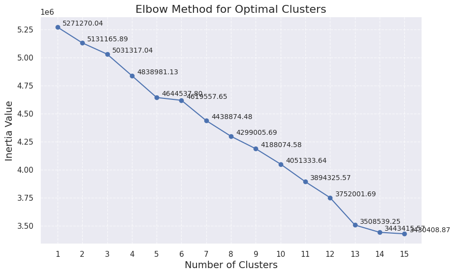

```python
# Plot Elbow Method with Labels
plt.figure(figsize=(10, 6))
plt.plot(range(1, 16), inersia_values, marker='o', linestyle='-', color='b')

# Menambahkan label untuk setiap titik data
for i, inertia in enumerate(inersia_values):
    plt.text(i + 1.2, inertia, f'{inertia:.2f}', ha='left', va='bottom', fontsize=10)

plt.title('Elbow Method for Optimal Clusters', fontsize=16)
plt.xlabel('Number of Clusters', fontsize=14)
plt.ylabel('Inertia Value', fontsize=14)
plt.xticks(range(1, 16))
plt.grid(True, linestyle='--', alpha=0.7)
plt.show()
```

Kode diatas digunakan untuk membuat visualisasi yang disebut "Elbow Method" untuk menemukan jumlah cluster yang optimal dalam algoritma KMeans. Berikut adalah penjelasan singkat dan tujuannya:

1. **Visualisasi Elbow Method**: Grafik menunjukkan jumlah cluster (sumbu x) terhadap nilai inersia (sumbu y). Inersia adalah ukuran seberapa jauh titik-titik data dalam sebuah cluster dari pusatnya. Semakin rendah nilai inersia, semakin "padat" atau "bersatu" cluster tersebut.
2. **Tujuan**: Elbow Method membantu kita menemukan jumlah cluster yang optimal untuk algoritma KMeans dengan melihat di mana ada "siku" pada grafik. Siku ini menunjukkan di mana penurunan nilai inersia mulai melambat secara signifikan. Jumlah cluster di sekitar siku ini seringkali dipilih sebagai jumlah cluster yang optimal, karena menambahkan lebih banyak cluster mungkin tidak memberikan manfaat yang signifikan dalam memahami struktur data.

Grafik juga menampilkan label yang menunjukkan nilai inersia pada setiap titik data, sehingga kita bisa melihat dengan tepat di mana penurunan inersia mulai melambat. Dengan menggunakan informasi ini, kita bisa membuat keputusan yang lebih baik tentang jumlah cluster yang akan digunakan dalam analisis clustering kita.

```python
data = transformed_data.copy()
```

```python
# Apply K-means clustering
km_2_pca = KMeans(n_clusters = 5,random_state=42, init = 'k-means++', n_init = 'auto', max_iter = 500, tol = 0.0001)
km_2_pca.fit(hasil_pca_sklearn)
predicted_labels = km_2_pca.labels_
```

```python
predicted_labels
```

```
array([1, 2, 2, ..., 1, 1, 1], dtype=int32)
```

```python
km_2_pca.cluster_centers_[:, 0], km_2_pca.cluster_centers_[:, 1]
```

```
(array([ 2.15667261, -0.71425583,  1.35234738,  3.33890378,  1.17086794]),
 array([-3.41945694,  1.10286539, -2.86655097,  2.94056511, -2.82957173]))
```

Kode diatas melakukan KMeans clustering pada data yang sudah diproses menggunakan PCA (Principal Component Analysis). Mari kita jelaskan setiap langkahnya:

1. **Pemilihan Jumlah Cluster**: Pada kode yang Anda berikan, jumlah cluster yang dipilih adalah 5 (n_clusters = 5). Ini berarti algoritma KMeans akan mengelompokkan data menjadi lima kelompok berbeda.
2. **Inisialisasi KMeans**: Objek KMeans didefinisikan dengan parameter yang diberikan, seperti jumlah cluster, metode inisialisasi centroid (init), jumlah iterasi maksimum (max_iter), dan toleransi untuk konvergensi (tol).
3. **Pelatihan Model**: KMeans dilatih pada data yang telah diproses menggunakan PCA. Ini berarti KMeans akan mencoba menemukan lima kelompok data yang memiliki variabilitas terkecil dalam setiap kelompok dan jarak yang maksimum antara kelompok-kelompok tersebut.
4. **Prediksi Labels**: Setelah pelatihan, KMeans akan mengembalikan label untuk setiap titik data, menandakan keanggotaannya dalam salah satu dari lima kelompok yang telah ditentukan.
5. **Pusat Cluster**: Anda juga mencetak pusat-pusat dari kelima cluster yang ditemukan oleh KMeans. Ini memberikan Anda pemahaman tentang di mana pusat-pusat cluster tersebut berada dalam ruang fitur yang telah direduksi oleh PCA.

Tujuan utama dari KMeans clustering adalah untuk mengelompokkan data ke dalam beberapa kelompok yang homogen berdasarkan pola yang ada dalam data. Dalam konteks yang lebih luas, KMeans clustering dapat membantu dalam pemahaman pola yang tersembunyi dalam data, segmentasi pelanggan, pemrosesan gambar, analisis teks, dan banyak aplikasi lainnya. Dalam kasus ini, mungkin tujuannya adalah untuk mengelompokkan data menjadi lima kelompok yang berbeda berdasarkan pola yang ada dalam data yang telah diproses dengan PCA.

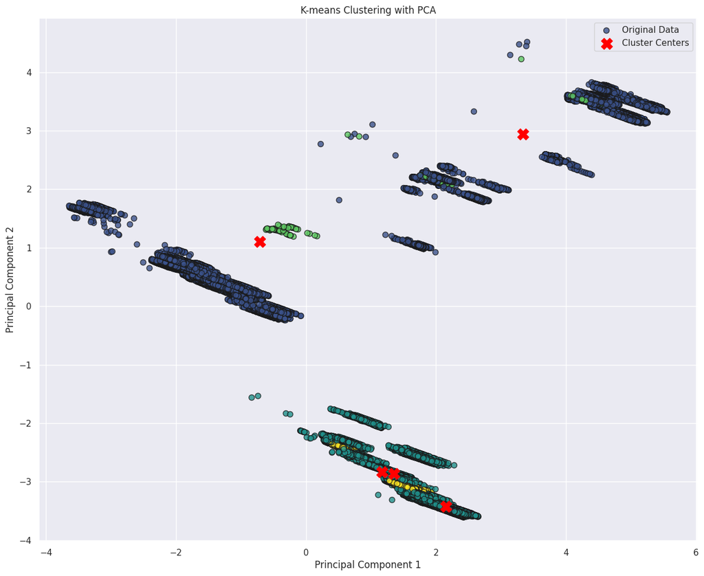

```python
# Create a larger figure
plt.figure(figsize=(15, 12))

# Plot the K-means clustered data points
plt.scatter(data[:, 0], data[:, 1], c=predicted_labels, cmap='viridis', edgecolor='k', s=50, alpha=0.8, label='Original Data')

# Plot the cluster centers
plt.scatter(km_2_pca.cluster_centers_[:, 0], km_2_pca.cluster_centers_[:, 1], c='red', marker='X', s=200, label='Cluster Centers')

# Add labels and title
plt.xlabel('Principal Component 1')
plt.ylabel('Principal Component 2')
plt.title('K-means Clustering with PCA')

# Show the legend
plt.legend()

# Show the plot
plt.show()
```

Kode tersebut adalah untuk membuat sebuah plot yang menampilkan hasil dari algoritma K-means clustering yang diterapkan pada data yang telah direduksi dimensinya menggunakan metode Principal Component Analysis (PCA).

Penjelasan komponen-komponen utama dari plot ini adalah sebagai berikut:

1. **Scatter Plot Data Asli**: Data asli direpresentasikan dalam scatter plot, di mana setiap titik mewakili satu sampel data. Warna titik-titik ini ditentukan oleh label yang diberikan oleh algoritma K-means clustering.
2. **Cluster Centers**: Titik-titik merah dengan simbol 'X' menunjukkan pusat dari masing-masing cluster yang diidentifikasi oleh algoritma K-means.
3. **Axis Label dan Title**: Label sumbu x dan y menunjukkan bahwa sumbu tersebut mewakili komponen utama 1 dan 2 dari hasil PCA. Judul plot memberikan informasi tentang jenis clustering yang dilakukan dan teknik reduksi dimensi yang digunakan.
4. **Legend**: Legend (keterangan) menunjukkan label yang diberikan kepada masing-masing kategori data, yaitu data asli dan pusat-pusat klaster.

```python
# Tambahkan kolom 'cluster' ke DataFrame 'data'
df_filtered['cluster'] = km_2_pca.labels_
```

Kode ini menambahkan kolom baru bernama 'cluster' ke dalam DataFrame 'df_filtered', yang berisi label klaster yang ditugaskan oleh algoritma K-means dengan menggunakan model yang telah ditransformasi menggunakan PCA.

```python
df_filtered.groupby('cluster').count()
```

| cluster | hari | bulan | tahun | barang | supplier | netto_kg | kelurahan | kecamatan | curah_hujan_kecamatan | hari_hujan_kecamatan | Luas | Jml_RT | Jml_RW | Jml_penduduk |
| --- | --- | --- | --- | --- | --- | --- | --- | --- | --- | --- | --- | --- | --- | --- |
| 0 | 169 | 169 | 169 | 169 | 169 | 169 | 169 | 169 | 169 | 169 | 169 | 169 | 169 | 169 |
| 1 | 41480 | 41480 | 41480 | 41480 | 41480 | 41480 | 41480 | 41480 | 41480 | 41480 | 41480 | 41480 | 41480 | 41480 |
| 2 | 15808 | 15808 | 15808 | 15808 | 15808 | 15808 | 15808 | 15808 | 15808 | 15808 | 15808 | 15808 | 15808 | 15808 |
| 3 | 1744 | 1744 | 1744 | 1744 | 1744 | 1744 | 1744 | 1744 | 1744 | 1744 | 1744 | 1744 | 1744 | 1744 |
| 4 | 1761 | 1761 | 1761 | 1761 | 1761 | 1761 | 1761 | 1761 | 1761 | 1761 | 1761 | 1761 | 1761 | 1761 |

Setelah itu, kode tersebut melakukan pengelompokan data berdasarkan label klaster yang baru ditambahkan, dan menghitung jumlah sampel data dalam setiap klaster.

```python
cluster_stats = df_filtered.groupby('cluster').mean()
cluster_stats
```

| cluster | hari | bulan | tahun | netto_kg | curah_hujan_kecamatan | hari_hujan_kecamatan | Luas | Jml_RT | Jml_RW | Jml_penduduk |
| --- | --- | --- | --- | --- | --- | --- | --- | --- | --- | --- |
| 0 | 16.183432 | 6.710059 | 2019.372781 | 2537.041420 | 176.700000 | 10.165680 | 7.120059 | 325.763314 | 69.751479 | 42866.603550 |
| 1 | 15.853737 | 6.466683 | 2020.975434 | 1198.096625 | 240.070576 | 15.329436 | 6.135397 | 317.963549 | 52.120926 | 42649.235029 |
| 2 | 15.923267 | 6.562184 | 2020.957174 | 1666.867535 | 234.852790 | 15.155807 | 6.801450 | 318.177379 | 61.786247 | 42408.057123 |
| 3 | 15.872706 | 6.400803 | 2020.864106 | 1188.281537 | 242.307454 | 15.317661 | 5.578296 | 361.073394 | 63.366972 | 42596.372133 |
| 4 | 16.182851 | 6.623509 | 2020.879046 | 901.208972 | 236.505792 | 15.130608 | 6.818041 | 318.572402 | 62.201022 | 42432.134583 |

Selanjutnya, kode menghitung statistik rata-rata untuk setiap fitur dalam setiap klaster menggunakan metode 'groupby' dan 'mean'. Hasilnya adalah DataFrame baru bernama 'cluster_stats', yang berisi nilai rata-rata dari setiap fitur untuk setiap klaster.

Tujuannya adalah untuk menganalisis perbedaan karakteristik antara klaster yang berbeda. Dengan kata lain, kita ingin melihat bagaimana nilai rata-rata dari fitur-fitur tertentu bervariasi di antara klaster-klaster tersebut. Informasi ini dapat memberikan wawasan yang berharga tentang pola-pola yang mungkin tersembunyi dalam data dan memungkinkan untuk pengambilan keputusan yang lebih baik dalam konteks analisis klaster.

```python
# Simpan DataFrame ke dalam file Excel
df_filtered.to_excel("data_hasil_clustering.xlsx", index=False)
```

Cluster 1

- Max : hari, bulan, netto_kg, Luas, Jml_RW, Jml_penduduk
- Min : tahun, curah_hujan_kecamatan, hari_hujan_kecamatan

Cluster 2

- Max : tahun, hari_hujan_kecamatan
- Min : hari, Jml_RT, Jml_RW

Cluster 3

Cluster 4

Cluster 5

Ini adalah interpretasi berdasarkan karakteristik yang Anda berikan. Jika ada informasi tambahan tentang klaster ketiga, saya dapat menyusun deskripsi yang lebih lengkap.

## Sampah Tidak Terpilah

```python
df_filtered.groupby('barang').size().sort_values(ascending = False).head(60)
```

```
barang
Sampah             59487
Sampah Terpilah     1468
0                      7
dtype: int64
```

```python
df_tdk_terpilah = df_filtered.loc[df_filtered["barang"] == "Sampah"]
df_tdk_terpilah.groupby('barang').size().sort_values(ascending = False).head(60)
```

```
barang
Sampah    59487
dtype: int64
```

```python
df_tdk_terpilah.groupby('cluster').mean()
```

| cluster | hari | bulan | tahun | netto_kg | curah_hujan_kecamatan | hari_hujan_kecamatan | Luas | Jml_RT | Jml_RW | Jml_penduduk |
| --- | --- | --- | --- | --- | --- | --- | --- | --- | --- | --- |
| 0 | 16.183432 | 6.710059 | 2019.372781 | 2537.041420 | 176.700000 | 10.165680 | 7.120059 | 325.763314 | 69.751479 | 42866.603550 |
| 1 | 15.849869 | 6.456611 | 2020.992683 | 1214.321338 | 239.728558 | 15.352778 | 6.130005 | 318.380772 | 52.229767 | 42615.352903 |
| 2 | 15.915034 | 6.555133 | 2020.957454 | 1667.846807 | 234.888086 | 15.153193 | 6.800892 | 318.164099 | 61.772304 | 42408.259400 |
| 3 | 15.853532 | 6.395750 | 2020.863871 | 1188.281447 | 242.414245 | 15.324526 | 5.577753 | 361.115451 | 63.377944 | 42599.492820 |
| 4 | 16.182851 | 6.623509 | 2020.879046 | 901.208972 | 236.505792 | 15.130608 | 6.818041 | 318.572402 | 62.201022 | 42432.134583 |

Pengklusteran untuk sampah yang tidak terpilah

Cluster 1

- Max : hari, bulan, netto_kg, Luas, Jml_RW, Jml_penduduk
- Min : tahun, curah_hujan_kecamatan, hari_hujan_kecamatan

Cluster 2

- Max : tahun, hari_hujan_kecamatan
- Min : hari, Jml_RW

Cluster 3

- Max :
- Min : Jml_RT,

Cluster 4

- Max : curah_hujan_kecamatan, Jml_RT
- Min : bulan, Luas

Cluster 5

### Cluster 1: Wilayah dengan Tingkat Penduduk dan Sampah Tertinggi

**Karakteristik:**

- **Max:** Wilayah-wilayah dalam klaster ini memiliki jumlah penduduk (Jml_penduduk) dan berat sampah yang terkumpul (netto_kg) yang tinggi. Luas wilayah yang tersedia (Luas) juga cukup besar, bersama dengan jumlah RW (Jml_RW). Aktivitas pengelolaan sampah cenderung tinggi dengan frekuensi harian (hari) dan bulanan (bulan) yang tinggi.
- **Min:** Variabel-variabel yang terkait dengan cuaca seperti tahun, curah hujan kecamatan, dan hari hujan kecamatan memiliki nilai terendah, menunjukkan bahwa faktor cuaca mungkin bukan pengaruh utama dalam pengelolaan sampah di wilayah-wilayah ini.

**Karakteristik:**

### Cluster 3: Wilayah dengan Fokus pada Pengelolaan Sampah di Tingkat Rumah Tangga

**Karakteristik:**

- **Max:** Tidak ada variabel yang memiliki nilai maksimum.
- **Min:** Variabel jumlah rumah tangga (Jml_RT) memiliki nilai terendah, menunjukkan bahwa klaster ini mungkin memiliki fokus pada pengelolaan sampah di tingkat rumah tangga daripada di tingkat wilayah.

### Cluster 4: Wilayah dengan Faktor Cuaca yang Memengaruhi

**Karakteristik:**

- **Max:** Curah hujan kecamatan dan jumlah rumah tangga (Jml_RT) memiliki nilai tertinggi.
- **Min:** Variabel bulan dan luas wilayah (Luas) memiliki nilai terendah, menunjukkan bahwa faktor cuaca, terutama curah hujan, mungkin memengaruhi pola pengelolaan sampah di wilayah-wilayah ini.

### Cluster 5: Wilayah dengan Tantangan Pengelolaan Sampah

Dengan memberikan label seperti ini, kita dapat lebih memahami ciri-ciri utama dari masing-masing klaster dan dapat merumuskan strategi pengelolaan sampah yang lebih efektif berdasarkan karakteristik klaster.

```python
df_tdk_terpilah.groupby('kecamatan').size().sort_values(ascending = False).head(60)
```

```
kecamatan
Magelang Utara      31421
Magelang Selatan    17701
Magelang Tengah     10365
dtype: int64
```

```python
df_tdk_terpilah.groupby('kelurahan').size().sort_values(ascending = False).head(60)
```

```
kelurahan
Kedungsari              16805
Potrobangsan             4708
Kramat Utara             4259
Magersari                4138
daerah lainnya           3746
Kemiri Rejo              2429
Rejowinangun Selatan     2414
Tidar Utara              2396
Tidar Selatan            2355
Wates                    2059
Jurangombo Utara         1997
Magelang                 1982
Kramat Selatan           1979
Jurangombo Selatan       1761
Panjang                  1741
Jurangombo               1495
Gelangan                 1263
Jurangombo UTara          927
Cacaban                   551
Rejowinangun Utara        482
dtype: int64
```

## Sampah Terpilah

```python
df_terpilah = df_filtered.loc[df_filtered["barang"] == "Sampah Terpilah"]
df_terpilah.groupby('barang').size().sort_values(ascending = False).head(60)
```

```
barang
Sampah Terpilah    1468
dtype: int64
```

```python
df_terpilah.groupby('cluster').mean()
```

| cluster | hari | bulan | tahun | netto_kg | curah_hujan_kecamatan | hari_hujan_kecamatan | Luas | Jml_RT | Jml_RW | Jml_penduduk |
| --- | --- | --- | --- | --- | --- | --- | --- | --- | --- | --- |
| 1 | 15.951782 | 6.748428 | 2020.491964 | 743.567435 | 249.762334 | 14.677848 | 6.285846 | 306.321454 | 49.083857 | 43598.578616 |
| 2 | 19.647059 | 9.588235 | 2020.823529 | 1154.117647 | 220.585294 | 16.205882 | 7.031176 | 323.647059 | 67.529412 | 42330.470588 |
| 3 | 27.000000 | 9.333333 | 2021.000000 | 1188.333333 | 180.333333 | 11.333333 | 5.893700 | 336.666667 | 57.000000 | 40785.333333 |

Pengklusteran untuk sampah yang terpilah

Cluster 2

- Max : curah_hujan_kecamatan, Jml_penduduk
- Min : hari, bulan,tahun, tahun, Jml_RT, Jml_RW

Cluster 3

- Max : bulan, hari_hujan_kecamatan, Luas, Jml_RW
- Min :

Cluster 4

Berikut adalah nama dan karakteristik untuk setiap klaster :

Cluster 2: "Penduduk Padat dengan Curah Hujan Tinggi"

- **Karakteristik**: Wilayah dalam klaster ini ditandai dengan populasi yang padat dan tingginya curah hujan di kecamatan. Namun, jumlah hari, bulan, tahun, serta jumlah rumah tangga (Jml_RT) dan jumlah RW (Jml_RW) cenderung lebih rendah.

Cluster 3: "Musim Hujan yang Mempengaruhi Wilayah Luas"

- **Karakteristik**: Klaster ini mencerminkan daerah dengan pengaruh musiman yang kuat, terutama dalam hal bulan, hari hujan di kecamatan, luas wilayah, dan jumlah RW. Tidak ada atribut yang mencapai nilai minimum yang signifikan.

Setiap klaster memberikan wawasan tentang karakteristik unik dari wilayah-wilayah tertentu terkait dengan atribut-atribut yang diberikan.

```python
df_terpilah.groupby('kecamatan').size().sort_values(ascending = False).head(60)
```

```
kecamatan
Magelang Utara      1419
Magelang Selatan      34
Magelang Tengah       15
dtype: int64
```

```python
df_terpilah.groupby('kelurahan').size().sort_values(ascending = False).head(60)
```

```
kelurahan
Potrobangsan            1399
Jurangombo UTara          17
Kedungsari                10
Magersari                  6
Kemiri Rejo                6
Wates                      4
Tidar Selatan              4
daerah lainnya             4
Kramat Utara               4
Panjang                    3
Rejowinangun Selatan       3
Magelang                   2
Tidar Utara                2
Jurangombo                 1
Rejowinangun Utara         1
Jurangombo Utara           1
Gelangan                   1
dtype: int64
```